# Assignment4-Will

```python
import numpy
import matplotlib.pyplot as plt
import sklearn as sk
```

### Preprocess

```python
import os
import pandas as pd

data_dir = "./data/SRP192714"
data_name = "SRP192714_Symbols.tsv"
metadata_name = "metadata_SRP192714_merged.tsv"
data_path = os.path.join(data_dir, data_name)
metadata_path = os.path.join(data_dir, metadata_name)

data = pd.read_csv(data_path, sep="\t", header=0)
with open(metadata_path, 'r', encoding='utf-8', errors='replace') as fh:
    metadata = pd.read_csv(fh, sep='\t', header=0)
```

```python
import numpy as np
numeric = data.select_dtypes(include=[np.number])
gene_var = numeric.var(axis=1)
data['gene_variance'] = gene_var
data_sorted = data.sort_values(by='gene_variance', ascending=False)
data_top5000 = data_sorted.head(5000).dropna(subset=['Symbol'])
metadata_clean = metadata[['refinebio_accession_code', 'Exposure']].dropna()
metadata_clean = metadata_clean.rename(columns={'refinebio_accession_code': 'sample_id'})
metadata_clean['patient_id'] = metadata_clean['sample_id'].str.extract(r'(SRR\d+)')
metadata_clean = metadata_clean.dropna(subset=['patient_id'])
```

```python
data_top5000
```

|  | Symbol | SRR8907879 | SRR8907880 | SRR8907881 | SRR8907882 | SRR8907883 | SRR8907884 | SRR8907885 | SRR8907886 | SRR8907887 | ... | SRR8908891 | SRR8908892 | SRR8908893 | SRR8908894 | SRR8908895 | SRR8908896 | SRR8908897 | SRR8908898 | SRR8908899 | gene_variance |
| --- | --- | --- | --- | --- | --- | --- | --- | --- | --- | --- | --- | --- | --- | --- | --- | --- | --- | --- | --- | --- | --- |
| 24102 | XIST | 3.427381 | 4.144367 | 3.255694 | 2.847241 | 3.346353 | 2.537812 | 2.637920 | 2.634947 | 3.274512 | ... | 120.350586 | 109.743807 | 112.462383 | 68.048351 | 69.191205 | 3.026146 | 2.885235 | 3.531275 | 2.773213 | 2915.342313 |
| 6527 | JCHAIN | 69.905350 | 70.659115 | 67.071661 | 65.554728 | 67.410360 | 67.071661 | 68.048351 | 69.191205 | 17.052993 | ... | 168.396935 | 87.812912 | 84.978226 | 49.076084 | 46.870443 | 179.135614 | 179.135614 | 112.462383 | 108.370810 | 2807.906735 |
| 39232 | RN7SL1 | 78.682248 | 78.186574 | 80.118708 | 79.648319 | 79.648319 | 79.177921 | 77.260285 | 79.648319 | 174.957746 | ... | 174.957746 | 152.307890 | 152.307890 | 79.177921 | 80.118708 | 70.279785 | 71.033559 | 134.648038 | 136.164870 | 2402.596672 |
| 7499 | IFI44L | 93.356831 | 96.637429 | 91.828849 | 92.607267 | 95.312695 | 101.287877 | 93.356831 | 94.647599 | 8.961745 | ... | 47.727332 | 98.876075 | 98.876075 | 152.307890 | 152.307890 | 58.457009 | 53.389534 | 13.477679 | 13.804107 | 2082.657070 |
| 4944 | IFIT3 | 71.775701 | 73.690123 | 76.826814 | 72.160454 | 71.775701 | 71.402244 | 79.177921 | 77.720565 | 18.730542 | ... | 69.905350 | 123.800749 | 124.986729 | 171.503648 | 171.503648 | 66.726271 | 66.726271 | 15.160584 | 15.339435 | 2072.916796 |
| ... | ... | ... | ... | ... | ... | ... | ... | ... | ... | ... | ... | ... | ... | ... | ... | ... | ... | ... | ... | ... | ... |
| 11281 | ELAPOR2 | 3.916609 | 2.900281 | 4.883377 | 3.696960 | 4.249975 | 3.952074 | 4.494100 | 4.118150 | 4.035264 | ... | 3.253993 | 3.301516 | 3.724175 | 2.795993 | 2.274137 | 3.580921 | 3.424288 | 3.002246 | 3.508450 | 0.723081 |
| 20652 | IGHV1-46 | 1.103100 | 0.196625 | 1.432086 | 1.112272 | 1.109563 | 1.118793 | 1.104604 | 0.199593 | 1.671912 | ... | 2.762262 | 1.225723 | 1.218041 | 1.216668 | 0.934286 | 2.070228 | 1.794337 | 0.051840 | 1.360349 | 0.722844 |
| 21282 | RPL17-C18orf32 | 2.629247 | 0.196625 | 2.726308 | 0.199846 | 2.571057 | 2.981186 | 2.184598 | 2.237283 | 2.049736 | ... | 2.587613 | 2.733967 | 2.748172 | 1.963880 | 1.737006 | 2.483376 | 2.136300 | 2.090409 | 1.647534 | 0.722704 |
| 10931 | EIF5A2 | 3.580384 | 4.723720 | 5.615663 | 3.404488 | 5.543651 | 4.467344 | 6.059459 | 5.713199 | 4.503632 | ... | 4.987284 | 3.930969 | 3.722670 | 4.189522 | 4.721575 | 4.251283 | 4.342737 | 4.500863 | 3.632151 | 0.722542 |
| 16678 | ZMYM1 | 5.792604 | 5.896217 | 7.699045 | 6.500447 | 6.773832 | 7.420544 | 6.321523 | 5.817931 | 5.479711 | ... | 5.936552 | 6.188460 | 5.567069 | 6.566985 | 5.628647 | 6.195972 | 5.665726 | 6.464715 | 5.991005 | 0.722540 |

4847 rows × 1023 columns

```python
print(f"Samples with exposure labels: {len(metadata_clean)}")
print(f"Unique patients: {metadata_clean['patient_id'].nunique()}")
print(f"Exposure distribution:\n{metadata_clean['Exposure'].value_counts()}")
```

```
Samples with exposure labels: 1021
Unique patients: 1021
Exposure distribution:
Exposure
naive    553
DENV     468
Name: count, dtype: int64
```

```python
# Prepare expression matrix (samples x genes)
expr_samples = data_top5000.drop(columns=['Symbol', 'gene_variance']).columns
common_samples = list(set(expr_samples) & set(metadata_clean['sample_id']))

# Transpose expression data to align with metadata
expr_matrix = data_top5000.drop(columns=['Symbol', 'gene_variance'])[common_samples].T
metadata_aligned = metadata_clean[metadata_clean['sample_id'].isin(common_samples)]
metadata_aligned = metadata_aligned.set_index('sample_id').loc[expr_matrix.index]

print(f"Final matrix shape: {expr_matrix.shape}")
print(f"Features (genes): {expr_matrix.shape[1]}")
print(f"Samples: {expr_matrix.shape[0]}")
```

```
Final matrix shape: (1021, 4847)
Features (genes): 4847
Samples: 1021
```

## Patient-Level Data Splitting

```python
from sklearn.model_selection import GroupShuffleSplit

# Get patient-level labels
patient_labels = metadata_aligned.groupby('patient_id')['Exposure'].first()

X_all = expr_matrix
y_all = metadata_aligned['Exposure']
groups_all = metadata_aligned['patient_id']

gss = GroupShuffleSplit(n_splits=1, test_size=0.3, random_state=42)
train_idx, test_idx = next(gss.split(X_all, y_all, groups=groups_all))

# train/test splits
X_train = X_all.iloc[train_idx]
X_test = X_all.iloc[test_idx]
y_train = y_all.iloc[train_idx]
y_test = y_all.iloc[test_idx]

# for later
train_patient_ids = groups_all.iloc[train_idx].unique()
test_patient_ids = groups_all.iloc[test_idx].unique()

print(f"Training: {X_train.shape[0]} samples, {len(train_patient_ids)} patients")
print(f"Testing: {X_test.shape[0]} samples, {len(test_patient_ids)} patients")
print(f"Train labels: {y_train.value_counts().to_dict()}")
print(f"Test labels: {y_test.value_counts().to_dict()}")
```

```
Training: 714 samples, 714 patients
Testing: 307 samples, 307 patients
Train labels: {'naive': 383, 'DENV': 331}
Test labels: {'naive': 170, 'DENV': 137}
```

## Binary Classification: DENV vs Naive

```python
from sklearn.svm import SVC
from sklearn.preprocessing import StandardScaler, LabelEncoder
from sklearn.pipeline import Pipeline
from sklearn.metrics import roc_auc_score, roc_curve, classification_report
import os

os.makedirs('results', exist_ok=True)
os.makedirs('plots', exist_ok=True)

# Convert string labels to binary
label_encoder = LabelEncoder()
y_train_binary = label_encoder.fit_transform(y_train)
y_test_binary = label_encoder.transform(y_test)

print(f"Label mapping: {dict(zip(label_encoder.classes_, [0, 1]))}")

# SVM pipeline with scaling
svm_binary = Pipeline([
    ('scaler', StandardScaler()),
    ('svm', SVC(kernel='rbf', probability=True, random_state=42))
])

svm_binary.fit(X_train, y_train_binary)

y_pred_proba = svm_binary.predict_proba(X_test)[:, 1]
y_pred = svm_binary.predict(X_test)

# Calculate ROC AUC
auc_score = roc_auc_score(y_test_binary, y_pred_proba)
print(f"Binary Classification AUC: {auc_score:.3f}")

print("\nClassification Report:")
print(classification_report(y_test_binary, y_pred, target_names=label_encoder.classes_))
```

```
Label mapping: {'DENV': 0, 'naive': 1}
```

```
Binary Classification AUC: 0.968

Classification Report:
              precision    recall  f1-score   support

        DENV       0.87      0.91      0.89       137
       naive       0.93      0.89      0.91       170

    accuracy                           0.90       307
   macro avg       0.90      0.90      0.90       307
weighted avg       0.90      0.90      0.90       307
```

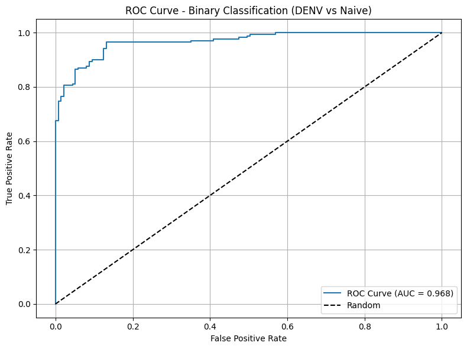

```python
# ROC Curve for Binary Classification
fpr, tpr, _ = roc_curve(y_test_binary, y_pred_proba)

plt.figure(figsize=(8, 6))
plt.plot(fpr, tpr, label=f'ROC Curve (AUC = {auc_score:.3f})')
plt.plot([0, 1], [0, 1], 'k--', label='Random')
plt.xlabel('False Positive Rate')
plt.ylabel('True Positive Rate')
plt.title('ROC Curve - Binary Classification (DENV vs Naive)')
plt.legend()
plt.grid(True)
plt.tight_layout()
plt.savefig('results/binary_roc_curve.png', dpi=300, bbox_inches='tight')
plt.show()
```

```python
# SVM Analysis with Different Numbers of Top Genes

import numpy as np
import pandas as pd
from sklearn.svm import SVC
from sklearn.preprocessing import StandardScaler, LabelEncoder
from sklearn.pipeline import Pipeline
from sklearn.metrics import roc_auc_score, accuracy_score, classification_report
import matplotlib.pyplot as plt

# Gene counts to test
gene_counts = [10, 100, 1000, 10000]
results_summary = {}

# Storage for results
all_results = []

print("=== SVM Analysis with Different Numbers of Top Genes ===\n")

for n_genes in gene_counts:
    print(f"Testing with top {n_genes} genes...")

    # Select top n genes
    if n_genes <= len(data_sorted):
        data_subset = data_sorted.head(n_genes)
    else:
        print(f"Only {len(data_sorted)} genes available, using all")
        data_subset = data_sorted
        n_genes = len(data_sorted)

    # Create expression matrix for this subset
    expr_matrix_subset = data_subset.drop(columns=['Symbol', 'gene_variance'])[common_samples].T
    expr_matrix_subset.columns = expr_matrix_subset.columns.astype(str)  # Fix column types

    # Use same train/test split
    X_train_subset = expr_matrix_subset.iloc[train_idx]
    X_test_subset = expr_matrix_subset.iloc[test_idx]

    # Binary Classification
    svm_binary_subset = Pipeline([
        ('scaler', StandardScaler()),
        ('svm', SVC(kernel='rbf', probability=True, random_state=42))
    ])

    svm_binary_subset.fit(X_train_subset, y_train_binary)
    y_pred_proba_subset = svm_binary_subset.predict_proba(X_test_subset)[:, 1]
    y_pred_subset = svm_binary_subset.predict(X_test_subset)

    # Calculate metrics
    auc_subset = roc_auc_score(y_test_binary, y_pred_proba_subset)
    accuracy_binary = accuracy_score(y_test_binary, y_pred_subset)

    # Cluster Classification (3 clusters)
    svm_cluster_subset = Pipeline([
        ('scaler', StandardScaler()),
        ('svm', SVC(kernel='rbf', probability=True, random_state=42))
    ])

    # Store results
    result = {
        'n_genes': n_genes,
        'binary_auc': auc_subset,
        'binary_accuracy': accuracy_binary,
        'n_features': X_train_subset.shape[1]
    }
    all_results.append(result)

    print(f"  Binary AUC: {auc_subset:.3f}")
    print(f"  Binary Accuracy: {accuracy_binary:.3f}")
    print(f"  Features used: {X_train_subset.shape[1]}\n")

# Convert results to DataFrame
results_df = pd.DataFrame(all_results)
print("=== Summary Table ===")
display(results_df)
```

```
=== SVM Analysis with Different Numbers of Top Genes ===

Testing with top 10 genes...
  Binary AUC: 0.763
  Binary Accuracy: 0.632
  Features used: 10

Testing with top 100 genes...
  Binary AUC: 0.949
  Binary Accuracy: 0.870
  Features used: 100

Testing with top 1000 genes...
```

```
  Binary AUC: 0.974
  Binary Accuracy: 0.912
  Features used: 1000

Testing with top 10000 genes...
```

```
  Binary AUC: 0.957
  Binary Accuracy: 0.893
  Features used: 10000

=== Summary Table ===
```

|  | n_genes | binary_auc | binary_accuracy | n_features |
| --- | --- | --- | --- | --- |
| 0 | 10 | 0.762602 | 0.631922 | 10 |
| 1 | 100 | 0.949334 | 0.869707 | 100 |
| 2 | 1000 | 0.973508 | 0.912052 | 1000 |
| 3 | 10000 | 0.957192 | 0.892508 | 10000 |

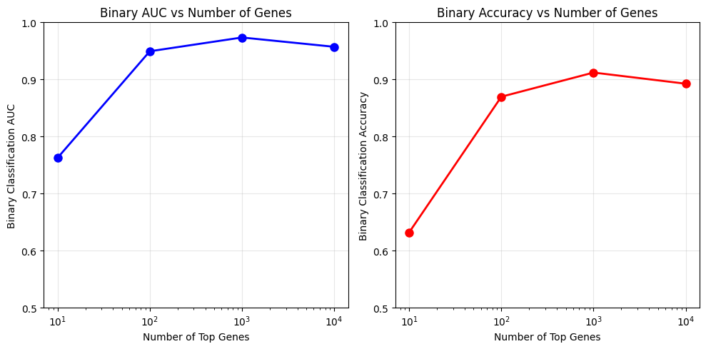

```python
# Plot results
fig, (ax1, ax2) = plt.subplots(1, 2, figsize=(10, 5))

# Binary AUC vs Number of Genes
ax1.semilogx(results_df['n_genes'], results_df['binary_auc'], 'bo-', linewidth=2, markersize=8)
ax1.set_xlabel('Number of Top Genes')
ax1.set_ylabel('Binary Classification AUC')
ax1.set_title('Binary AUC vs Number of Genes')
ax1.grid(True, alpha=0.3)
ax1.set_ylim([0.5, 1.0])

# Binary Accuracy vs Number of Genes
ax2.semilogx(results_df['n_genes'], results_df['binary_accuracy'], 'ro-', linewidth=2, markersize=8)
ax2.set_xlabel('Number of Top Genes')
ax2.set_ylabel('Binary Classification Accuracy')
ax2.set_title('Binary Accuracy vs Number of Genes')
ax2.grid(True, alpha=0.3)
ax2.set_ylim([0.5, 1.0])

plt.tight_layout()
plt.savefig('results/gene_count_performance.png', dpi=300, bbox_inches='tight')
plt.show()
```

As we can see, the AUC increases until about 1000 genes. Then, it begins to decrease. This is likely because the SVM is learning the noise associated with housekeeping genes instead of the data that actually matters. This is why it was important to select the top 5000 most variable genes in the first place, I imagine.

## Clustering for Multi-class Prediction

```python
from sklearn.cluster import AgglomerativeClustering
from sklearn.decomposition import PCA

# Use PCA for dimensionality reduction before clustering
pca = PCA(n_components=50, random_state=42)
X_pca = pca.fit_transform(StandardScaler().fit_transform(X_all))

# Agglomerative clustering (hierarchical from assignment 3
agg_clust_2 = AgglomerativeClustering(n_clusters=2)
agg_clust_3 = AgglomerativeClustering(n_clusters=3)
agg_clust_30 = AgglomerativeClustering(n_clusters=30)
cluster_labels_2 = agg_clust_2.fit_predict(X_pca)
cluster_labels_3 = agg_clust_3.fit_predict(X_pca)

# Add cluster labels to metadata
metadata_with_clusters = metadata_aligned.copy()
metadata_with_clusters['cluster_2'] = cluster_labels_2
metadata_with_clusters['cluster_3'] = cluster_labels_3

print(f"Cluster distribution: {np.bincount(cluster_labels_2)}")
print(f"Cluster distribution: {np.bincount(cluster_labels_3)}")
print(f"Clusters vs Exposure:")
cluster_exposure_table2 = pd.crosstab(metadata_with_clusters['cluster_2'], metadata_with_clusters['Exposure'])
cluster_exposure_table3 = pd.crosstab(metadata_with_clusters['cluster_3'], metadata_with_clusters['Exposure'])
print(cluster_exposure_table2)
print(cluster_exposure_table3)
```

```
Cluster distribution: [905 116]
Cluster distribution: [677 116 228]
Clusters vs Exposure:
Exposure   DENV  naive
cluster_2
0           402    503
1            66     50
Exposure   DENV  naive
cluster_3
0           326    351
1            66     50
2            76    152
```

The clustering groups seem to have odd proportions of DENV and naive patients.

```python
# SVM for cluster prediction
y_clusters_train_3 = metadata_with_clusters['cluster_3'].iloc[train_idx]
y_clusters_test_3 = metadata_with_clusters['cluster_3'].iloc[test_idx]

y_clusters_train_2 = metadata_with_clusters['cluster_2'].iloc[train_idx]
y_clusters_test_2 = metadata_with_clusters['cluster_2'].iloc[test_idx]
# Multi-class SVM
svm_multiclass = Pipeline([
    ('scaler', StandardScaler()),
    ('svm', SVC(kernel='rbf', probability=True, random_state=42))
])
# fit 3 clusters
svm_multiclass.fit(X_train, y_clusters_train_3)
y_clusters_pred_3 = svm_multiclass.predict(X_test)
y_clusters_proba_3 = svm_multiclass.predict_proba(X_test)
# fit 2 clusters
svm_multiclass.fit(X_train, y_clusters_train_2)
y_clusters_pred_2 = svm_multiclass.predict(X_test)
y_clusters_proba_2 = svm_multiclass.predict_proba(X_test)


# Multi-class accuracy
from sklearn.metrics import accuracy_score, confusion_matrix
cluster_accuracy = accuracy_score(y_clusters_test_3, y_clusters_pred_3)
print(f"Cluster Prediction Accuracy (3 clusters): {cluster_accuracy:.3f}")

cluster_accuracy = accuracy_score(y_clusters_test_2, y_clusters_pred_2)
print(f"Cluster Prediction Accuracy (2 clusters): {cluster_accuracy:.3f}")


print("\nConfusion Matrix:")
print(confusion_matrix(y_clusters_test_3, y_clusters_pred_3))
print(confusion_matrix(y_clusters_test_2, y_clusters_pred_2))
```

```
Cluster Prediction Accuracy (3 clusters): 0.987
Cluster Prediction Accuracy (2 clusters): 0.997

Confusion Matrix:
[[204   0   2]
 [  1  31   0]
 [  1   0  68]]
[[275   0]
 [  1  31]]
```

The confusion matrix seems to indicate that fitting our data to 2 clusters is just nearly as good as fitting it to 3. This might indicate that there are more subtle biological relationships among out patients' gene expression than we realized at first. This was evident in assignment 3, when we saw that there were potentially 30 different gene expression patterns among our patients. However, it is more likely that the model could just be fitting to patient immune subtypes/age/sex differences.

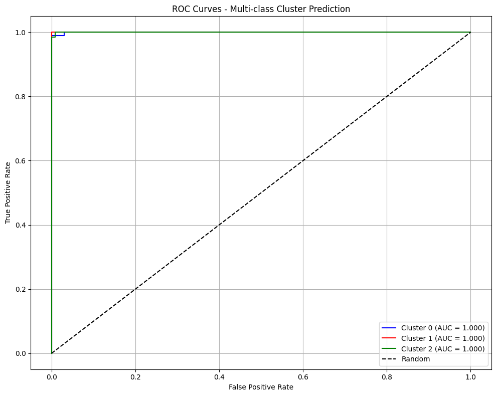

```python
# Multi-class ROC (One-vs-Rest)
from sklearn.metrics import roc_curve, auc
from sklearn.preprocessing import label_binarize

# Binarize labels for multi-class ROC
y_test_bin = label_binarize(y_clusters_test_3, classes=list(range(3)))
n_classes = y_test_bin.shape[1]

# Calculate ROC for each class
fpr_multi = dict()
tpr_multi = dict()
roc_auc_multi = dict()

plt.figure(figsize=(10, 8))
colors = ['blue', 'red', 'green']

for i in range(n_classes):
    fpr_multi[i], tpr_multi[i], _ = roc_curve(y_test_bin[:, i], y_clusters_proba_3[:, i])
    roc_auc_multi[i] = auc(fpr_multi[i], tpr_multi[i])
    plt.plot(fpr_multi[i], tpr_multi[i], color=colors[i],
             label=f'Cluster {i} (AUC = {roc_auc_multi[i]:.3f})')

plt.plot([0, 1], [0, 1], 'k--', label='Random')
plt.xlabel('False Positive Rate')
plt.ylabel('True Positive Rate')
plt.title('ROC Curves - Multi-class Cluster Prediction')
plt.legend()
plt.grid(True)
plt.tight_layout()
plt.savefig('results/multiclass_roc_curves_clust-30.png', dpi=300, bbox_inches='tight')
plt.show()
```

## Heatmap Visualization

```python
# Get top variable genes for heatmap (since RBF kernel doesn't have coef_)
# Use the top 50 most variable genes from our original selection
top_genes_indices = np.arange(50)  # First 50 genes from data_top5000 (already sorted by variance)
top_gene_names = data_top5000['Symbol'].iloc[top_genes_indices].values

# Create heatmap data
heatmap_data = expr_matrix.iloc[:, top_genes_indices].T

# Z-score normalization (row-wise for genes)
gene_means = heatmap_data.mean(axis=1)
gene_stds = heatmap_data.std(axis=1)
heatmap_data_scaled = heatmap_data.sub(gene_means, axis=0).div(gene_stds, axis=0)

# Handle any NaN values (genes with zero variance)
heatmap_data_scaled = heatmap_data_scaled.fillna(0)

# Create annotation for samples
sample_colors = {'DENV': 'red', 'naive': 'blue'}
exposure_colors = [sample_colors.get(exp, 'gray') for exp in metadata_aligned['Exposure']]

cluster_colors = ['gold', 'lightgreen', 'lightcoral']
cluster_sample_colors = [cluster_colors[c] for c in metadata_with_clusters['cluster_3']]

print(f"Heatmap shape: {heatmap_data_scaled.shape}")
print(f"Top {len(top_gene_names)} most variable genes selected")
print(f"Using genes with highest variance from original selection")
```

```
Heatmap shape: (50, 1021)
Top 50 most variable genes selected
Using genes with highest variance from original selection
```

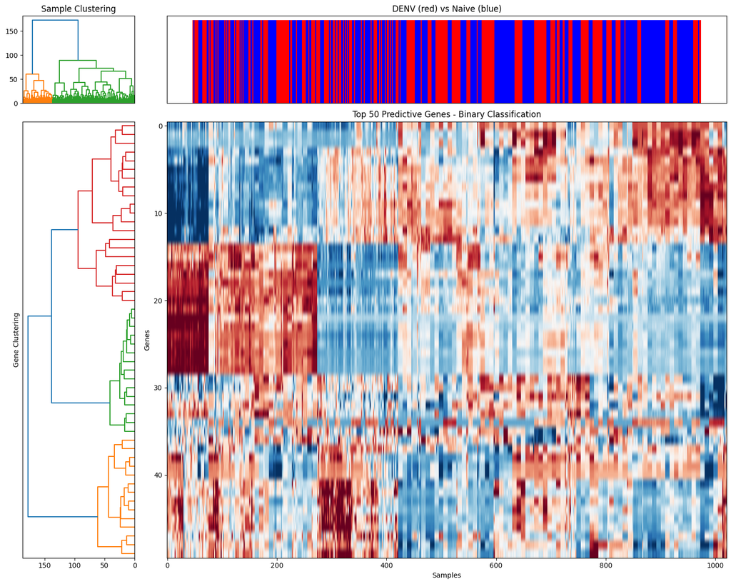

```python
# Binary Classification Heatmap
from scipy.cluster.hierarchy import dendrogram, linkage
from scipy.spatial.distance import pdist

plt.figure(figsize=(15, 10))

# Calculate linkage for dendrogram
sample_linkage = linkage(pdist(heatmap_data_scaled.T), method='ward')
gene_linkage = linkage(pdist(heatmap_data_scaled), method='ward')

# Create subplots
fig, ((ax_dendro_col, ax_colorbar), (ax_dendro_row, ax_heatmap)) = plt.subplots(
    2, 2, figsize=(15, 12),
    gridspec_kw={'height_ratios': [0.2, 1], 'width_ratios': [0.2, 1]}
)

# Column dendrogram
dendro_col = dendrogram(sample_linkage, ax=ax_dendro_col, orientation='top', no_labels=True)
ax_dendro_col.set_xticks([])
ax_dendro_col.set_title('Sample Clustering')

# Row dendrogram
dendro_row = dendrogram(gene_linkage, ax=ax_dendro_row, orientation='left', no_labels=True)
ax_dendro_row.set_yticks([])
ax_dendro_row.set_ylabel('Gene Clustering')

# Reorder data based on dendrograms
col_order = dendro_col['leaves']
row_order = dendro_row['leaves']

heatmap_ordered = heatmap_data_scaled.iloc[row_order, col_order]

# Main heatmap
im = ax_heatmap.imshow(heatmap_ordered, cmap='RdBu_r', aspect='auto', vmin=-2, vmax=2)
ax_heatmap.set_title('Top 50 Predictive Genes - Binary Classification')
ax_heatmap.set_xlabel('Samples')
ax_heatmap.set_ylabel('Genes')

# Color bar for exposure
exposure_ordered = [exposure_colors[i] for i in col_order]
ax_colorbar.bar(range(len(exposure_ordered)), [1]*len(exposure_ordered),
               color=exposure_ordered, width=1.0)
ax_colorbar.set_title('DENV (red) vs Naive (blue)')
ax_colorbar.set_xticks([])
ax_colorbar.set_yticks([])

plt.tight_layout()
plt.savefig('results/binary_heatmap_dendrogram.png', dpi=300, bbox_inches='tight')
plt.show()
```

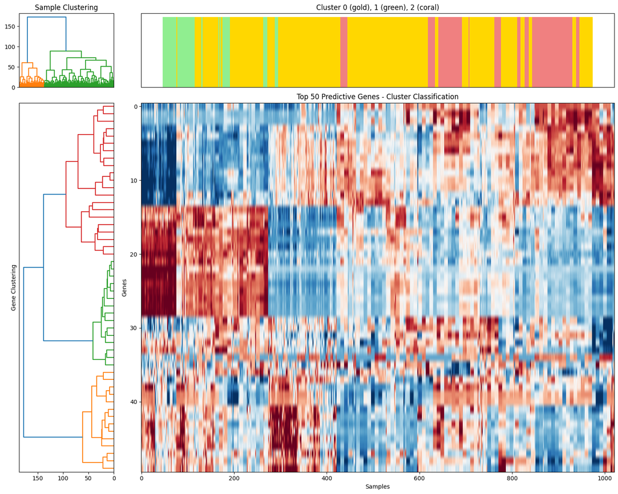

```python
# Cluster Prediction Heatmap
fig, ((ax_dendro_col2, ax_colorbar2), (ax_dendro_row2, ax_heatmap2)) = plt.subplots(
    2, 2, figsize=(15, 12),
    gridspec_kw={'height_ratios': [0.2, 1], 'width_ratios': [0.2, 1]}
)

# Same dendrograms (genes and samples don't change)
dendrogram(sample_linkage, ax=ax_dendro_col2, orientation='top', no_labels=True)
ax_dendro_col2.set_xticks([])
ax_dendro_col2.set_title('Sample Clustering')

dendrogram(gene_linkage, ax=ax_dendro_row2, orientation='left', no_labels=True)
ax_dendro_row2.set_yticks([])
ax_dendro_row2.set_ylabel('Gene Clustering')

# Main heatmap (same gene ordering)
im2 = ax_heatmap2.imshow(heatmap_ordered, cmap='RdBu_r', aspect='auto', vmin=-2, vmax=2)
ax_heatmap2.set_title('Top 50 Predictive Genes - Cluster Classification')
ax_heatmap2.set_xlabel('Samples')
ax_heatmap2.set_ylabel('Genes')

# Color bar for clusters
cluster_ordered = [cluster_sample_colors[i] for i in col_order]
ax_colorbar2.bar(range(len(cluster_ordered)), [1]*len(cluster_ordered),
                color=cluster_ordered, width=1.0)
ax_colorbar2.set_title('Cluster 0 (gold), 1 (green), 2 (coral)')
ax_colorbar2.set_xticks([])
ax_colorbar2.set_yticks([])

plt.tight_layout()
plt.savefig('results/cluster_heatmap_dendrogram.png', dpi=300, bbox_inches='tight')
plt.show()
```

This clustering heatmap / dendrogram seems to reflect the binary classification that we had done earlier. However, from here we can also see that the cluster bands do not seem to be reflecting any particular groups from binary classification. Further analysis would be necessary, but for now it could be that there are other factors effecting the clustering results more than the DENV vs naive label.

## Results Summary

```python
# Save final results summary
results_summary = {
    'Binary_Classification_AUC': auc_score,
    'Cluster_Prediction_Accuracy': cluster_accuracy,
    'N_Training_Samples': X_train.shape[0],
    'N_Test_Samples': X_test.shape[0],
    'N_Genes': X_train.shape[1],
    'N_Patients_Train': len(train_patient_ids),
    'N_Patients_Test': len(test_patient_ids)
}

# Save to file
import json
with open('results/svm_results_summary.json', 'w') as f:
    json.dump(results_summary, f, indent=2)

print("=== SVM Analysis Results ===")
print(f"Binary Classification (DENV vs Naive):")
print(f"  - AUC Score: {auc_score:.3f}")
print(f"  - Test Samples: {X_test.shape[0]}")

print(f"\nCluster Prediction:")
print(f"  - Accuracy: {cluster_accuracy:.3f}")
print(f"  - Number of Clusters: 3")

print(f"\nData Split:")
print(f"  - Training: {X_train.shape[0]} samples from {len(train_patient_ids)} patients")
print(f"  - Testing: {X_test.shape[0]} samples from {len(test_patient_ids)} patients")
print(f"  - Features: {X_train.shape[1]} genes")

print(f"\nFiles saved to results/:")
print("  - binary_roc_curve.png")
print("  - multiclass_roc_curves.png")
print("  - binary_heatmap_dendrogram.png")
print("  - cluster_heatmap_dendrogram.png")
print("  - svm_results_summary.json")
```

[output not shown]

```python
# 1. Binary Classification Predictions
binary_predictions = pd.DataFrame({
    'sample_id': X_test.index,
    'true_label': [label_encoder.classes_[i] for i in y_test_binary],
    'predicted_label': [label_encoder.classes_[i] for i in y_pred],
    'predicted_correctly': y_test_binary == y_pred,
    'probability_class_0': svm_binary.predict_proba(X_test)[:, 0],
    'probability_class_1': svm_binary.predict_proba(X_test)[:, 1],
    'confidence': np.max(svm_binary.predict_proba(X_test), axis=1)
})

# Add patient information
binary_predictions['patient_id'] = metadata_aligned.loc[binary_predictions['sample_id'], 'patient_id'].values

print("=== Binary Classification Predictions ===")
print(f"Total test samples: {len(binary_predictions)}")
print(f"Correctly predicted: {binary_predictions['predicted_correctly'].sum()}")
print(f"Accuracy: {binary_predictions['predicted_correctly'].mean():.3f}")
print("\nFirst 10 predictions:")
display(binary_predictions.head(10))

# 2. Cluster Classification Predictions (3 clusters)
cluster_predictions_3 = pd.DataFrame({
    'sample_id': X_test.index,
    'true_cluster': y_clusters_test_3.values,
    'predicted_cluster': y_clusters_pred_3,
    'predicted_correctly': y_clusters_test_3.values == y_clusters_pred_3,
})

# Add probabilities for each cluster
for i in range(3):
    cluster_predictions_3[f'probability_cluster_{i}'] = y_clusters_proba_3[:, i]

cluster_predictions_3['confidence'] = np.max(y_clusters_proba_3, axis=1)
cluster_predictions_3['patient_id'] = metadata_aligned.loc[cluster_predictions_3['sample_id'], 'patient_id'].values
cluster_predictions_3['exposure'] = metadata_aligned.loc[cluster_predictions_3['sample_id'], 'Exposure'].values

print("\n=== 3-Cluster Classification Predictions ===")
print(f"Total test samples: {len(cluster_predictions_3)}")
print(f"Correctly predicted: {cluster_predictions_3['predicted_correctly'].sum()}")
print(f"Accuracy: {cluster_predictions_3['predicted_correctly'].mean():.3f}")
print("\nFirst 10 predictions:")
display(cluster_predictions_3.head(10))

# 3. Cluster Classification Predictions (2 clusters)
cluster_predictions_2 = pd.DataFrame({
    'sample_id': X_test.index,
    'true_cluster': y_clusters_test_2.values,
    'predicted_cluster': y_clusters_pred_2,
    'predicted_correctly': y_clusters_test_2.values == y_clusters_pred_2,
})

# Add probabilities for each cluster
for i in range(2):
    cluster_predictions_2[f'probability_cluster_{i}'] = y_clusters_proba_2[:, i]

cluster_predictions_2['confidence'] = np.max(y_clusters_proba_2, axis=1)
cluster_predictions_2['patient_id'] = metadata_aligned.loc[cluster_predictions_2['sample_id'], 'patient_id'].values
cluster_predictions_2['exposure'] = metadata_aligned.loc[cluster_predictions_2['sample_id'], 'Exposure'].values

print("\n=== 2-Cluster Classification Predictions ===")
print(f"Total test samples: {len(cluster_predictions_2)}")
print(f"Correctly predicted: {cluster_predictions_2['predicted_correctly'].sum()}")
print(f"Accuracy: {cluster_predictions_2['predicted_correctly'].mean():.3f}")
print("\nFirst 10 predictions:")
display(cluster_predictions_2.head(10))

# 4. Summary by Patient (for binary classification)
patient_summary = binary_predictions.groupby('patient_id').agg({
    'predicted_correctly': ['count', 'sum', 'mean'],
    'confidence': 'mean',
    'true_label': 'first'
}).round(3)

patient_summary.columns = ['total_samples', 'correct_predictions', 'accuracy', 'avg_confidence', 'true_exposure']
patient_summary = patient_summary.reset_index()

print("\n=== Patient-Level Summary (Binary Classification) ===")
print("Accuracy per patient:")
display(patient_summary.head(10))

# 5. Misclassified Samples Analysis
misclassified_binary = binary_predictions[~binary_predictions['predicted_correctly']].copy()
misclassified_clusters_3 = cluster_predictions_3[~cluster_predictions_3['predicted_correctly']].copy()

print(f"\n=== Misclassified Samples ===")
print(f"Binary classification errors: {len(misclassified_binary)}")
if len(misclassified_binary) > 0:
    print("Binary misclassifications:")
    display(misclassified_binary[['sample_id', 'patient_id', 'true_label', 'predicted_label', 'confidence']])

print(f"\n3-cluster classification errors: {len(misclassified_clusters_3)}")
if len(misclassified_clusters_3) > 0:
    print("Cluster misclassifications:")
    display(misclassified_clusters_3[['sample_id', 'patient_id', 'true_cluster', 'predicted_cluster', 'confidence', 'exposure']])

# 6. Save all prediction matrices
os.makedirs('results', exist_ok=True)
binary_predictions.to_csv('results/svm_binary_predictions.csv', index=False)
cluster_predictions_3.to_csv('results/svm_cluster3_predictions.csv', index=False)
cluster_predictions_2.to_csv('results/svm_cluster2_predictions.csv', index=False)
patient_summary.to_csv('results/svm_patient_summary.csv', index=False)

print(f"\n=== Files Saved ===")
print("- results/svm_binary_predictions.csv")
print("- results/svm_cluster3_predictions.csv")
print("- results/svm_cluster2_predictions.csv")
print("- results/svm_patient_summary.csv")
```

```
=== Binary Classification Predictions ===
Total test samples: 307
Correctly predicted: 276
Accuracy: 0.899

First 10 predictions:
```

|  | sample_id | true_label | predicted_label | predicted_correctly | probability_class_0 | probability_class_1 | confidence | patient_id |
| --- | --- | --- | --- | --- | --- | --- | --- | --- |
| 0 | SRR8908211 | DENV | DENV | True | 0.870046 | 0.129954 | 0.870046 | SRR8908211 |
| 1 | SRR8908804 | naive | naive | True | 0.004230 | 0.995770 | 0.995770 | SRR8908804 |
| 2 | SRR8907955 | DENV | DENV | True | 0.980159 | 0.019841 | 0.980159 | SRR8907955 |
| 3 | SRR8907963 | DENV | DENV | True | 0.914416 | 0.085584 | 0.914416 | SRR8907963 |
| 4 | SRR8908590 | DENV | DENV | True | 0.977113 | 0.022887 | 0.977113 | SRR8908590 |
| 5 | SRR8908395 | DENV | DENV | True | 0.990573 | 0.009427 | 0.990573 | SRR8908395 |
| 6 | SRR8908772 | naive | DENV | False | 0.649143 | 0.350857 | 0.649143 | SRR8908772 |
| 7 | SRR8908745 | DENV | DENV | True | 0.984448 | 0.015552 | 0.984448 | SRR8908745 |
| 8 | SRR8908477 | naive | naive | True | 0.039715 | 0.960285 | 0.960285 | SRR8908477 |
| 9 | SRR8908303 | DENV | naive | False | 0.421954 | 0.578046 | 0.578046 | SRR8908303 |

```
=== 3-Cluster Classification Predictions ===
Total test samples: 307
Correctly predicted: 303
Accuracy: 0.987

First 10 predictions:
```

|  | sample_id | true_cluster | predicted_cluster | predicted_correctly | probability_cluster_0 | probability_cluster_1 | probability_cluster_2 | confidence | patient_id | exposure |
| --- | --- | --- | --- | --- | --- | --- | --- | --- | --- | --- |
| 0 | SRR8908211 | 2 | 2 | True | 0.005545 | 0.002885 | 0.991570 | 0.991570 | SRR8908211 | DENV |
| 1 | SRR8908804 | 2 | 2 | True | 0.000167 | 0.002254 | 0.997579 | 0.997579 | SRR8908804 | naive |
| 2 | SRR8907955 | 0 | 0 | True | 0.997537 | 0.001047 | 0.001416 | 0.997537 | SRR8907955 | DENV |
| 3 | SRR8907963 | 0 | 0 | True | 0.986260 | 0.013378 | 0.000362 | 0.986260 | SRR8907963 | DENV |
| 4 | SRR8908590 | 0 | 0 | True | 0.975800 | 0.009805 | 0.014395 | 0.975800 | SRR8908590 | DENV |
| 5 | SRR8908395 | 0 | 0 | True | 0.998745 | 0.000907 | 0.000348 | 0.998745 | SRR8908395 | DENV |
| 6 | SRR8908772 | 0 | 0 | True | 0.999957 | 0.000034 | 0.000010 | 0.999957 | SRR8908772 | naive |
| 7 | SRR8908745 | 1 | 1 | True | 0.011054 | 0.981782 | 0.007164 | 0.981782 | SRR8908745 | DENV |
| 8 | SRR8908477 | 0 | 0 | True | 0.980564 | 0.000312 | 0.019123 | 0.980564 | SRR8908477 | naive |
| 9 | SRR8908303 | 1 | 1 | True | 0.000005 | 0.999038 | 0.000957 | 0.999038 | SRR8908303 | DENV |

```
=== 2-Cluster Classification Predictions ===
Total test samples: 307
Correctly predicted: 306
Accuracy: 0.997

First 10 predictions:
```

|  | sample_id | true_cluster | predicted_cluster | predicted_correctly | probability_cluster_0 | probability_cluster_1 | confidence | patient_id | exposure |
| --- | --- | --- | --- | --- | --- | --- | --- | --- | --- |
| 0 | SRR8908211 | 0 | 0 | True | 0.999113 | 0.000887 | 0.999113 | SRR8908211 | DENV |
| 1 | SRR8908804 | 0 | 0 | True | 0.997526 | 0.002474 | 0.997526 | SRR8908804 | naive |
| 2 | SRR8907955 | 0 | 0 | True | 0.999069 | 0.000931 | 0.999069 | SRR8907955 | DENV |
| 3 | SRR8907963 | 0 | 0 | True | 0.988570 | 0.011430 | 0.988570 | SRR8907963 | DENV |
| 4 | SRR8908590 | 0 | 0 | True | 0.989311 | 0.010689 | 0.989311 | SRR8908590 | DENV |
| 5 | SRR8908395 | 0 | 0 | True | 0.999056 | 0.000944 | 0.999056 | SRR8908395 | DENV |
| 6 | SRR8908772 | 0 | 0 | True | 0.999968 | 0.000032 | 0.999968 | SRR8908772 | naive |
| 7 | SRR8908745 | 1 | 1 | True | 0.007492 | 0.992508 | 0.992508 | SRR8908745 | DENV |
| 8 | SRR8908477 | 0 | 0 | True | 0.999844 | 0.000156 | 0.999844 | SRR8908477 | naive |
| 9 | SRR8908303 | 1 | 1 | True | 0.000002 | 0.999998 | 0.999998 | SRR8908303 | DENV |

```
=== Patient-Level Summary (Binary Classification) ===
Accuracy per patient:
```

|  | patient_id | total_samples | correct_predictions | accuracy | avg_confidence | true_exposure |
| --- | --- | --- | --- | --- | --- | --- |
| 0 | SRR8907881 | 1 | 1 | 1.0 | 0.984 | naive |
| 1 | SRR8907882 | 1 | 1 | 1.0 | 0.967 | naive |
| 2 | SRR8907884 | 1 | 1 | 1.0 | 0.952 | naive |
| 3 | SRR8907888 | 1 | 1 | 1.0 | 0.699 | naive |
| 4 | SRR8907889 | 1 | 1 | 1.0 | 0.990 | naive |
| 5 | SRR8907902 | 1 | 1 | 1.0 | 0.909 | DENV |
| 6 | SRR8907904 | 1 | 1 | 1.0 | 0.930 | DENV |
| 7 | SRR8907908 | 1 | 1 | 1.0 | 0.922 | DENV |
| 8 | SRR8907909 | 1 | 1 | 1.0 | 0.937 | DENV |
| 9 | SRR8907910 | 1 | 1 | 1.0 | 0.940 | DENV |

```
=== Misclassified Samples ===
Binary classification errors: 31
Binary misclassifications:
```

|  | sample_id | patient_id | true_label | predicted_label | confidence |
| --- | --- | --- | --- | --- | --- |
| 6 | SRR8908772 | SRR8908772 | naive | DENV | 0.649143 |
| 9 | SRR8908303 | SRR8908303 | DENV | naive | 0.578046 |
| 18 | SRR8908515 | SRR8908515 | naive | DENV | 0.515042 |
| 21 | SRR8908145 | SRR8908145 | naive | DENV | 0.940442 |
| 33 | SRR8908302 | SRR8908302 | DENV | naive | 0.528094 |
| 37 | SRR8908144 | SRR8908144 | naive | DENV | 0.958716 |
| 41 | SRR8908427 | SRR8908427 | naive | DENV | 0.969407 |
| 67 | SRR8908472 | SRR8908472 | naive | DENV | 0.602684 |
| 98 | SRR8908835 | SRR8908835 | naive | DENV | 0.751930 |
| 105 | SRR8908426 | SRR8908426 | naive | DENV | 0.961974 |
| 119 | SRR8908413 | SRR8908413 | naive | DENV | 0.931354 |
| 120 | SRR8908446 | SRR8908446 | DENV | naive | 0.584913 |
| 128 | SRR8908437 | SRR8908437 | DENV | naive | 0.818729 |
| 143 | SRR8908536 | SRR8908536 | naive | DENV | 0.711836 |
| 147 | SRR8907942 | SRR8907942 | naive | DENV | 0.588806 |
| 162 | SRR8907946 | SRR8907946 | naive | DENV | 0.600409 |
| 163 | SRR8907945 | SRR8907945 | naive | DENV | 0.505188 |
| 177 | SRR8908573 | SRR8908573 | DENV | naive | 0.815127 |
| 193 | SRR8908231 | SRR8908231 | DENV | naive | 0.902214 |
| 198 | SRR8908193 | SRR8908193 | naive | DENV | 0.571512 |
| 199 | SRR8908412 | SRR8908412 | naive | DENV | 0.954664 |
| 209 | SRR8907944 | SRR8907944 | naive | DENV | 0.578198 |
| 240 | SRR8908447 | SRR8908447 | DENV | naive | 0.551624 |
| 243 | SRR8908574 | SRR8908574 | DENV | naive | 0.947419 |
| 253 | SRR8908821 | SRR8908821 | naive | DENV | 0.605829 |
| 257 | SRR8908378 | SRR8908378 | DENV | naive | 0.766264 |
| 276 | SRR8908572 | SRR8908572 | DENV | naive | 0.812559 |
| 288 | SRR8908230 | SRR8908230 | DENV | naive | 0.911921 |
| 294 | SRR8908895 | SRR8908895 | DENV | naive | 0.575062 |
| 296 | SRR8907975 | SRR8907975 | naive | DENV | 0.634732 |
| 298 | SRR8907939 | SRR8907939 | naive | DENV | 0.564950 |

```
3-cluster classification errors: 4
Cluster misclassifications:
```

|  | sample_id | patient_id | true_cluster | predicted_cluster | confidence | exposure |
| --- | --- | --- | --- | --- | --- | --- |
| 27 | SRR8907949 | SRR8907949 | 0 | 2 | 0.677799 | naive |
| 36 | SRR8907951 | SRR8907951 | 0 | 2 | 0.650708 | naive |
| 145 | SRR8908616 | SRR8908616 | 2 | 0 | 0.593017 | naive |
| 160 | SRR8908135 | SRR8908135 | 1 | 0 | 0.841984 | DENV |

```
=== Files Saved ===
- results/svm_binary_predictions.csv
- results/svm_cluster3_predictions.csv
- results/svm_cluster2_predictions.csv
- results/svm_patient_summary.csv
```

```python
# Check how well clusters align with exposure
from sklearn.metrics import adjusted_rand_score

# Convert exposure to binary for comparison
exposure_binary = label_encoder.fit_transform(metadata_aligned['Exposure'])
cluster_labels_2_all = metadata_with_clusters['cluster_2']

# Calculate agreement between clusters and exposure
ari_score = adjusted_rand_score(exposure_binary, cluster_labels_2_all)
print(f"Adjusted Rand Index between clusters and exposure: {ari_score:.3f}")

# Show the crosstab more clearly
print("\nCluster vs Exposure crosstab:")
crosstab = pd.crosstab(cluster_labels_2_all, metadata_aligned['Exposure'], margins=True)
print(crosstab)

# Calculate what percentage of each cluster is each exposure
crosstab_pct = pd.crosstab(cluster_labels_2_all, metadata_aligned['Exposure'], normalize='index')
print("\nPercentage breakdown:")
print(crosstab_pct)
```

```
Adjusted Rand Index between clusters and exposure: 0.009

Cluster vs Exposure crosstab:
Exposure   DENV  naive   All
cluster_2
0           402    503   905
1            66     50   116
All         468    553  1021

Percentage breakdown:
Exposure       DENV     naive
cluster_2
0          0.444199  0.555801
1          0.568966  0.431034
```